# Notebook

Notebook to viz FaIR output

I am currently running this notebook to viz the results from running FaIR `project` from within a sandbox. You will need to use the `fair_env` to run the notebook.

### Notebook Env: fair_env

located at `/Users/pk695/werk.M2/FACTS_dev/2401_RFF.SPs/facts_development/envs/fair_env/bin`  
activate

- Terminal `source /Users/pk695/werk.M2/FACTS_dev/2401_RFF.SPs/facts_development/envs/fair_env/bin/activate`
- Jupyter: Change the kernel in the toolbar to run the notebook.

  **If the kernel does not appear:**
  - Restart and install the new kernel using:

    ```
    ipython kernel install --user --name=fair_env
    ```

  - If that does not work, install `ipykernel`:

    ```
    pip install ipykernel
    ```

1. `rffemissions` has 3 gasses - 'C' 'CH4' 'N2' , IDX (0,1,2)
2. `emis` and `rffemfull_array` have at "C" ,"CH4" ,"N2O" ,"N2" , IDX (1,3,4,4)
   - first column is time.

Load FaIR data at the project stage

```
 <======>
rffemissions =   Size: 68MB
Dimensions:    (rff_sp: 10000, Year: 281, gas: 3)
Coordinates:
  * rff_sp     (rff_sp) int64 80kB 1 2 3 4 5 6 ... 9996 9997 9998 9999 10000
  * Year       (Year) int64 2kB 2020 2021 2022 2023 2024 ... 2297 2298 2299 2300
  * gas        (gas) object 24B 'C' 'CH4' 'N2'
Data variables:
    emissions  (gas, rff_sp, Year) float64 67MB 11.08 11.21 ... 0.1785 0.1785
Attributes:
    Description:      A compilation of 3-ghg gas emissions files from RFF con...
    Version:          v2. These emissions current as of end of Jan/early Feb ...
    Emissions Units:  C: Gt/C, CH4: Mt/CH4, N2O: Mt/N2
    Source files:     impactlab-data/gcp/integration/RFF-SP/v2/emissions/
<======>
emis shape::  (751, 40)
<======>
rffemfull_array shape:: (10, 751, 40)
<======>
```

Plot:: FaIR IP emissions

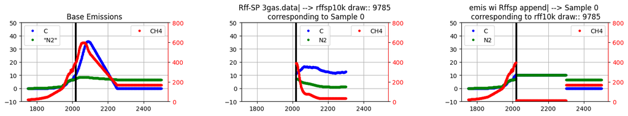

```
<Figure size 1750x237.5 with 6 Axes>
```

```
sample=0
```

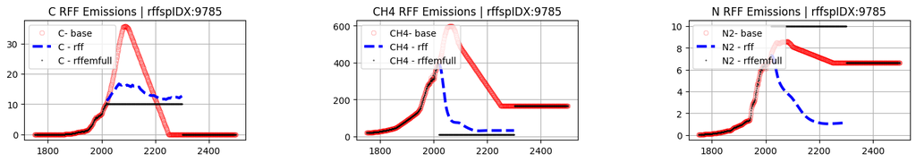

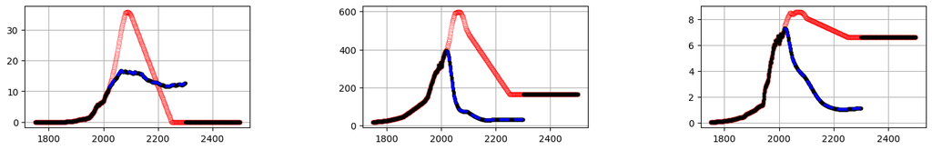

```
sample=1
```

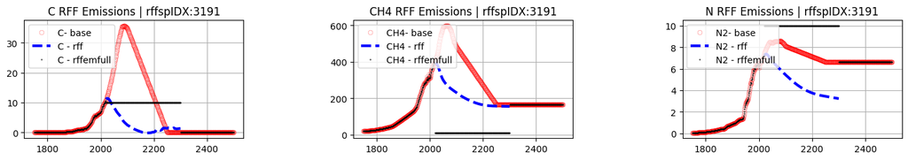

```
<Figure size 1750x237.5 with 3 Axes>
```

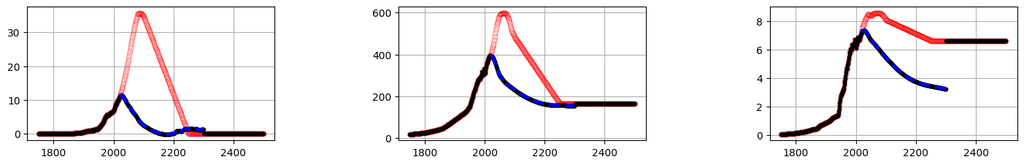

```
<Figure size 1750x237.5 with 3 Axes>
```

```
sample=2
```

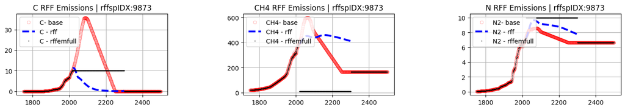

```
<Figure size 1750x237.5 with 3 Axes>
```

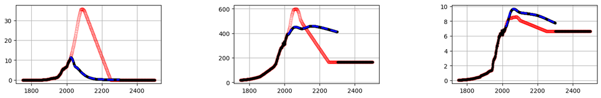

```
<Figure size 1750x237.5 with 3 Axes>
```

```
sample=3
```

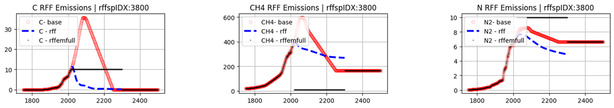

```
<Figure size 1750x237.5 with 3 Axes>
```

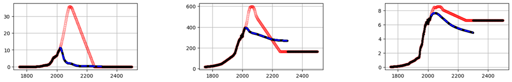

```
<Figure size 1750x237.5 with 3 Axes>
```

```
sample=4
```

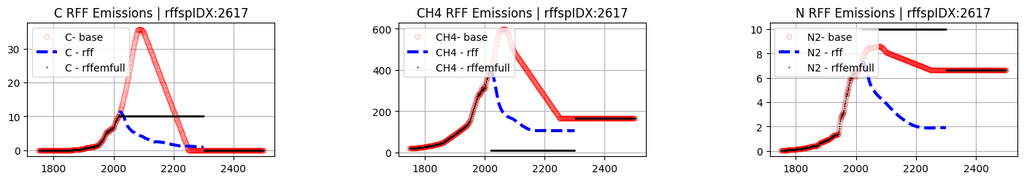

```
<Figure size 1750x237.5 with 3 Axes>
```

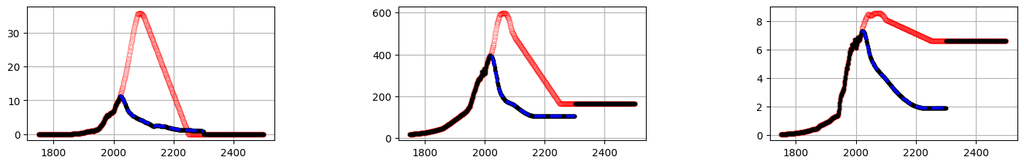

```
<Figure size 1750x237.5 with 3 Axes>
```

```
sample=5
```

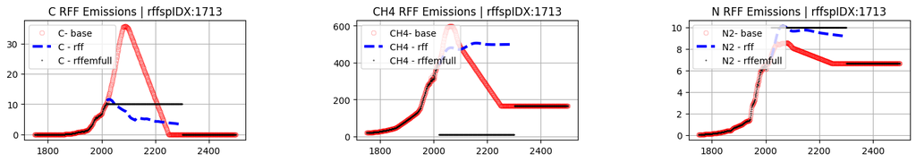

```
<Figure size 1750x237.5 with 3 Axes>
```

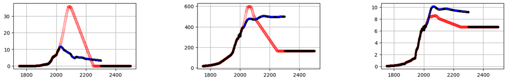

```
<Figure size 1750x237.5 with 3 Axes>
```

```
sample=6
```

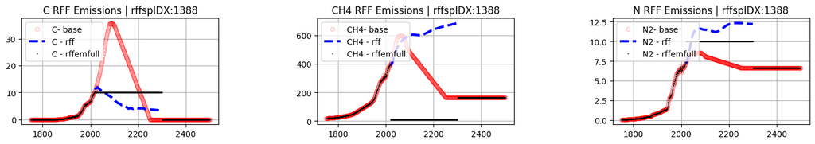

```
<Figure size 1750x237.5 with 3 Axes>
```

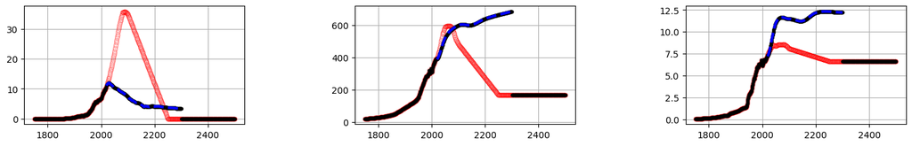

```
<Figure size 1750x237.5 with 3 Axes>
```

```
sample=7
```

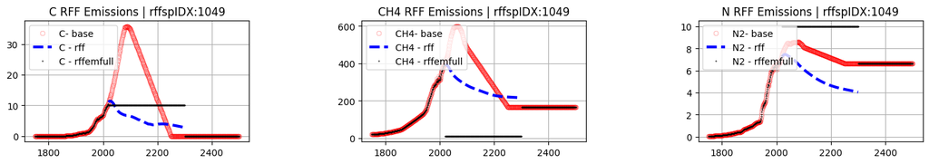

```
<Figure size 1750x237.5 with 3 Axes>
```

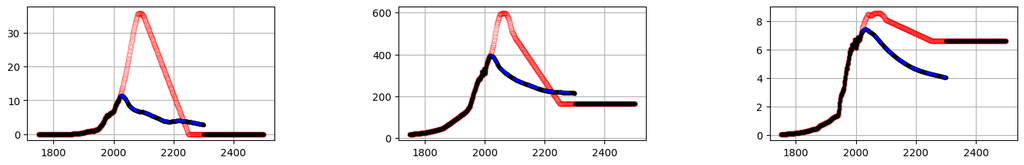

```
<Figure size 1750x237.5 with 3 Axes>
```

```
sample=8
```

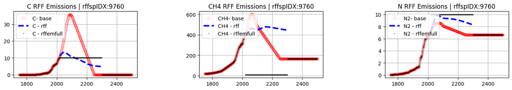

```
<Figure size 1750x237.5 with 3 Axes>
```

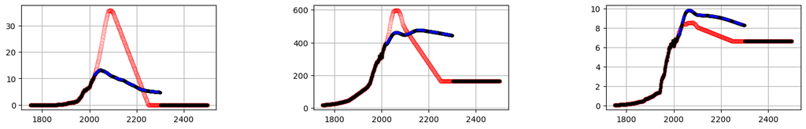

```
<Figure size 1750x237.5 with 3 Axes>
```

```
sample=9
```

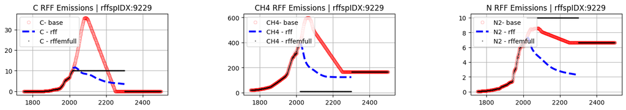

```
<Figure size 1750x237.5 with 3 Axes>
```

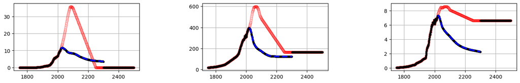

```
<Figure size 1750x237.5 with 3 Axes>
```

Recalc above in nbk

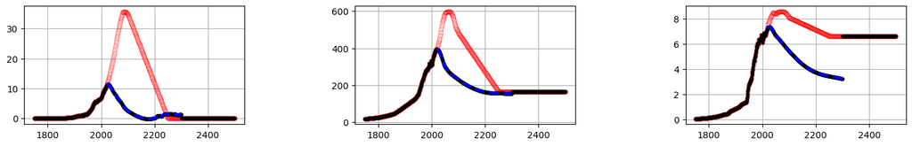

```
<Figure size 1750x237.5 with 3 Axes>
```

3 Gas

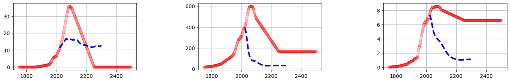

```
<Figure size 1750x237.5 with 3 Axes>
```

Check gas tract from OG Emissions Data